**https://www.journaldev.com/python-tutorial**

# Python Class

==> Python has been an object-oriented language since it existed. Because of this, creating and using classes and objects are downright easy.

### Terms using in class

**Class** − A user-defined prototype for an object that defines a set of attributes that characterize any object of the class. The attributes are data members (class variables and instance variables) and methods, accessed via dot notation.

**Class variable** − A variable that is shared by all instances of a class. Class variables are defined within a class but outside any of the class's methods. Class variables are not used as frequently as instance variables are.

**Data member** − A class variable or instance variable that holds data associated with a class and its objects.

**Function overloading** − The assignment of more than one behavior to a particular function. The operation performed varies by the types of objects or arguments involved.

**Instance variable** − A variable that is defined inside a method and belongs only to the current instance of a class.

**Inheritance** − The transfer of the characteristics of a class to other classes that are derived from it.

**Instance** − An individual object of a certain class. An object obj that belongs to a class Circle, for example, is an instance of the class Circle.

**Instantiation** − The creation of an instance of a class.

**Method** − A special kind of function that is defined in a class definition.

**Object** − A unique instance of a data structure that's defined by its class. An object comprises both data members (class variables and instance variables) and methods.

**Operator overloading** − The assignment of more than one function to a particular operator.

### Create Class

==> The class statement creates a new class definition. The name of the class immediately follows the keyword **class** followed by a **colon**

```python
class ClassName:
   "Document of String"
```

==> The class has a documentation string, which can be accessed via ClassName. **doc**.

```python
class Employee:
   'Common base class for all employees'
   empCount = 0

   def __init__(self, name, salary):
      self.name = name
      self.salary = salary
      Employee.empCount += 1

   def displayCount(self):
     print ("Total Employee %d" , Employee.empCount)

   def displayEmployee(self):
      print ("Name : ", self.name,  ", Salary: ", self.salary)
```

==> The variable empCount is a class variable whose value is shared among all instances of a this class. This can be accessed as Employee.empCount from inside the class or outside the class.

==> The first method **init**() is a special method, which is called class constructor or initialization method that Python calls when you create a new instance of this class.

==> You declare other class methods like normal functions with the exception that the first argument to each method is self. Python adds the self argument to the list for you; you do not need to include it when you call the methods.

### Creating Instance Objects

==> To create instances of a class, you call the class using class name and pass in whatever arguments its **init** method accepts.

```python
"This would create first object of Employee class"
emp1 = Employee("Zara", 2000)
"This would create second object of Employee class"
emp2 = Employee("Manni", 5000)
```

### Accessing Attributes

```python
emp1.name
```

```
'Zara'
```

```python
emp2.empCount
```

```
2
```

```python
emp1.displayEmployee()
emp2.displayEmployee()
print ("Total Employee :" , Employee.empCount)
```

```
Name :  Zara , Salary:  2000
Name :  Manni , Salary:  5000
Total Employee : 2
```

==> You can add, remove, or modify attributes of classes and objects at any time

```python
emp1.age = 7  # Add an 'age' attribute.
emp1.age = 8  # Modify 'age' attribute.
del emp1.age  # Delete 'age' attribute.
```

==> Instead of using the normal statements to access attributes, you can use the following functions

==> The **getattr(obj, name[, default])** ===> to access the attribute of object.

==> The **hasattr(obj,name)** ===> to check if an attribute exists or not.

==> The **setattr(obj,name,value)** ===> to set an attribute. If attribute does not exist, then it would be created.

==> The **delattr(obj, name)** ===> to delete an attribute.

```python
emp1.age = 7 #we deleted brfore so we have to set again
```

```python
hasattr(emp1, 'age')    # Returns true if 'age' attribute exists
getattr(emp1, 'age')    # Returns value of 'age' attribute
setattr(emp1, 'age', 8) # Set attribute 'age' at 8
delattr(emp1, 'age')    # Delete attribute 'age'
```

### Built-In Class Attributes

==> Every Python class keeps following built-in attributes and they can be accessed using dot operator like any other attribute.

==> **dict** ===> Dictionary containing the class's namespace.

==> **doc** ===> Class documentation string or none, if undefined.

==> **name** ===> Class name.

==> **module** ===> Module name in which the class is defined. This attribute is "**main**" in interactive mode.

==> **bases** ===> A possibly empty tuple containing the base classes, in the order of their occurrence in the base class list.

```python
print ("Employee.__doc__:", Employee.__doc__)
print ("Employee.__name__:", Employee.__name__)
print ("Employee.__module__:", Employee.__module__)
print ("Employee.__bases__:", Employee.__bases__)
print ("Employee.__dict__:", Employee.__dict__)
```

```
Employee.__doc__: Common base class for all employees
Employee.__name__: Employee
Employee.__module__: __main__
Employee.__bases__: (<class 'object'>,)
Employee.__dict__: {'__module__': '__main__', '__doc__': 'Common base class for all employees', 'empCount': 2, '__init__': <function Employee.__init__ at 0x000002AA52AFE730>, 'displayCount': <function Employee.displayCount at 0x000002AA52AFE268>, 'displayEmployee': <function Employee.displayEmployee…
```

## Self Variable

==> self represents the instance of the class.

==> By using the **“self”** keyword we can access the attributes and methods of the class in python.

==> The reason you need to use self. is because Python does not use the @ syntax to refer to instance attributes.

==> Python decided to do methods in a way that makes the instance to which the method belongs be passed automatically, but not received automatically: the first parameter of methods is the instance the method is called on

==> **Self is a convention and not a real python keyword**

```python
class car():

    # init method or constructor
    def __init__(self, model, color):
        self.model = model
        self.color = color

    def show(self):
        print("Model is", self.model )
        print("color is", self.color )

# both objects have different self which
# contain their attributes
audi = car("audi a4", "blue")
ferrari = car("ferrari 488", "green")

audi.show()	 # same output as car.show(audi)
ferrari.show() # same output as car.show(ferrari)

# Behind the scene, in every instance method
# call, python sends the instances also with
# that method call like car.show(audi)
```

```
Model is audi a4
color is blue
Model is ferrari 488
color is green
```

## Constructor

==> Constructors are generally used for instantiating an object.

==> The task of constructors is to initialize(assign values) to the data members of the class when an object of class is created.

==> In Python the **init**() method is called the constructor and is always called when an object is created.

**Types of constructors :**

==> **default constructor** : The default constructor is simple constructor which doesn’t accept any arguments.It’s definition has only one argument which is a reference to the instance being constructed.

==> **parameterized constructor** : constructor with parameters is known as parameterized constructor.The parameterized constructor take its first argument as a reference to the instance being constructed known as self and the rest of the arguments are provided by the programmer.

#### Example of default constructor :

```python
class University:
    Python = ""

    # default constructor
    def __init__(self):
        self.Python = "Artificial Intelligence"

    # a method for printing data members
    def print_ML(self):
        print(self.Python)


# creating object of the class
obj = University()

# calling the instance method using the object obj
obj.print_ML()
```

```
Artificial Intelligence
```

#### Example of parameterized constructor :

```python
class Addition:
    first = 0
    second = 0
    answer = 0

    # parameterized constructor
    def __init__(self, f, s):
        self.first = f
        self.second = s

    def display(self):
        print("First number = " + str(self.first))
        print("Second number = " + str(self.second))
        print("Addition of two numbers = " + str(self.answer))

    def calculate(self):
        self.answer = self.first + self.second

# creating object of the class
# this will invoke parameterized constructor
obj = Addition(1000, 2000)

# perform Addition
obj.calculate()

# display result
obj.display()
```

```
First number = 1000
Second number = 2000
Addition of two numbers = 3000
```

### **init**() is not a constructor

==> One important conclusion that can be drawn from the information so far is that, **init**() is not a constructor.

==> Python programmers get confused with it since **init**() gets called when we create an object.

==> A closer inspection will reveal that the first parameter in **init**() is the object itself (object already exists).

==> The function **init**() is called immediately after the object is created and is used to initialize it.

## Instance Methods of class

==> Instance methods are the most common type of methods in Python classes. These are so called because they can access unique data of their instance.

==> If you have two objects each created from a car class, then they each may have different properties. They may have different colors, engine sizes, seats, and so on.

==> Instance methods must have self as a parameter, but you don’t need to pass this in every time.

==> Self is another Python special term. Inside any instance method, you can use self to access any data or methods that may reside in your class. You won’t be able to access them without going through self.

==> Finally, as instance methods are the most common, there’s no decorator needed. Any method you create will automatically be created as an instance method.

```python
class InstanceMethod:
  def __init__(self):
    """ Example Setup """
    print('Hello, World!')
    self.name = 'InstanceMethod_Example'

  def example_function(self):
    """ This method is an instance method! """
    print('I\'m an instance method!')
    print('My name is ' + self.name)

de = InstanceMethod()
de.example_function()
```

```
Hello, World!
I'm an instance method!
My name is InstanceMethod_Example
```

==> The **name** variable is accessed through **self**. Notice that when **example_function** is called, you don’t have to pass self in Python does this for you.

## Static Methods of class

==> Static methods are methods that are related to a class in some way, but don’t need to access any class-specific data.

==> You don’t have to use **self**, and you don’t even need to instantiate an instance, you can simply call your method:

```python
class staticMethod:
  """ Example Class """
  def __init__(self):
    """ Example Setup """
    print('Hello, World!')

  @staticmethod
  def example_function():
    """ This method is a static method! """
    print('I\'m a static method!')

de = staticMethod.example_function()
```

```
I'm a static method!
```

==> The **@staticmethod** decorator was used to tell Python that this method is a static method.

==> Static methods are great for utility functions, which perform a task in isolation. They don’t need to (and cannot) access class data. They should be completely self-contained, and only work with data passed in as arguments. You may use a static method to add two numbers together, or print a given string.

## Class Methods of Python

==> Class methods are the third and final OOP method type to know. Class methods know about their class. They can’t access specific instance data, but they can call other static methods.

==> Class methods don’t need self as an argument, but they do need a parameter called cls. This stands for class, and like self, gets automatically passed in by Python.

==> Class methods are created using the **@classmethod**.

```python
class classMethod:
  """ Example Class """
  def __init__(self):
    """ Example Setup """
    print('Hello, World!')

  @classmethod
  def example_function(cls):
    """ This method is a class method! """
    print('I\'m a class method!')
    cls.some_other_function()

  @staticmethod
  def some_other_function():
    print('Hello!')

de = classMethod()
de.example_function()
```

```
Hello, World!
I'm a class method!
Hello!
```

==> Class methods are possibly the more confusing method types of the three, but they do have their uses. Class methods can manipulate the class itself, which is useful when you’re working on larger, more complex projects.

## Short Summary

**Instance Methods**: The most common method type. Able to access data and properties unique to each instance.

**Static Methods**: Cannot access anything else in the class. Totally self-contained code.

**Class Methods**: Can access limited methods in the class. Can modify class specific details.

```python
# Python program to demonstrate
# use of class method and static method.
from datetime import date

class Person:
    def __init__(self, name, age):
        self.name = name
        self.age = age

    # a class method to create a Person object by birth year.
    @classmethod
    def fromBirthYear(cls, name, year):
        return cls(name, date.today().year - year)


    # a static method to check if a Person is adult or not.
    @staticmethod
    def isAdult(age):
        return age > 18
```

```python
person1 = Person('mayank', 21)
person2 = Person.fromBirthYear('mayank', 1996)
```

```python
print (person1.age)
print (person2.age)
```

```
21
23
```

```python
# print the result
print (Person.isAdult(22))
```

```
True
```

```python
print(date.today())
```

```
2019-08-27
```

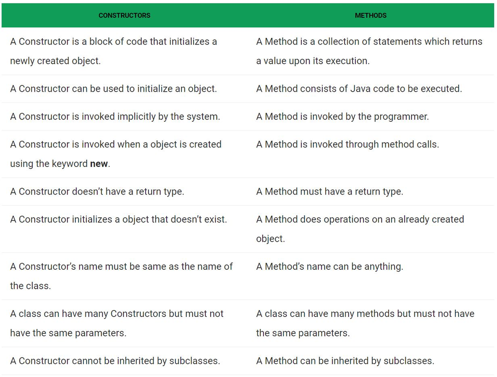

## Class Special Methods

#### What Are Dunder Methods?

==> They are easy to recognize because they start and end with double underscores, for example **init** or **str**

==> you can have good easy representation of class you dont have to write more code, basically code is optimize also....

```python
class NoLenSupport:
    pass
```

```python
obj = NoLenSupport()
len(obj)
```

```
----------------------------------------------------------------------
TypeError                            Traceback (most recent call last)
<ipython-input-23-d116e0b1802e> in <module>
      1 obj = NoLenSupport()
----> 2 len(obj)

TypeError: object of type 'NoLenSupport' has no len()
```

==> To fix this, you can add a **len** dunder method to your class:

```python
class LenSupport:
    def __len__(self):
        return 42
```

```python
obj = LenSupport()
len(obj)
```

```
42
```

### 1. Object Initialization: **__**init__

==> To construct account objects from the Account class I need a constructor which in Python is the **init** dunder:

```python
class Account:
    """A simple account class"""

    def __init__(self, owner, amount=0):
        """
        This is the constructor that lets us create
        objects from this class
        """
        self.owner = owner
        self.amount = amount
        self._transactions = []
```

==> The constructor takes care of setting up the object. In this case it receives the owner name, an optional start amount and defines an internal transactions list to keep track of deposits and withdrawals.

```python
acc = Account('bob')  # default amount = 0
```

```python
acc = Account('bob', 10)
```

```python
acc.amount
```

```
10
```

```python
acc.owner
```

```
'bob'
```

### 2. Object Representation: **__**str**, *__***repr__

1. **__**repr__ : The “official” string representation of an object. This is how you would make an object of the class.
2. **__**str__ : The “informal” or nicely printable string representation of an object.

```python
class Account:

    def __init__(self, owner, amount=0):
        """
        This is the constructor that lets us create
        objects from this class
        """
        self.owner = owner
        self.amount = amount
        self._transactions = []

    def __repr__(self):
        return 'Account({!r}, {!r})'.format(self.owner, self.amount)

    def __str__(self):
        return 'Account of {} with starting amount: {}'.format(self.owner, self.amount)
```

```python
acc = Account('bob', 10)
```

```python
str(acc)
```

```
'Account of bob with starting amount: 10'
```

```python
repr(acc)
```

```
"Account('bob', 10)"
```

```python
print(acc)
```

```
Account of bob with starting amount: 10
```

```python
acc.__repr__()
```

```
"Account('bob', 10)"
```

```python
acc.__str__()
```

```
'Account of bob with starting amount: 10'
```

### 3. Iteration: **__**len**, *__***getitem**, *__***reversed__

==> In order to iterate over our account object I need to add some transactions.

==> So first, I’ll define a simple method to add transactions.

==> I’ll keep it simple because this is just setup code to explain dunder methods, and not a production-ready accounting system

```python
class Account:

    def __init__(self, owner, amount=0):
        """
        This is the constructor that lets us create
        objects from this class
        """
        self.owner = owner
        self.amount = amount
        self._transactions = []

    def add_transaction(self, amount):
        if not isinstance(amount, int):
            raise ValueError('please use int for amount')
        self._transactions.append(amount)

    def __repr__(self):
        return 'Account({!r}, {!r})'.format(self.owner, self.amount)

    def __str__(self):
        return 'Account of {} with starting amount: {}'.format(self.owner, self.amount)
```

==> I also defined a **property** to calculate the balance on the account so I can conveniently access it with account.balance. This method takes the start amount and adds a sum of all the transactions:

```python
class Account:

    def __init__(self, owner, amount=0):
        """
        This is the constructor that lets us create
        objects from this class
        """
        self.owner = owner
        self.amount = amount
        self._transactions = []

    def add_transaction(self, amount):
        if not isinstance(amount, int):
            raise ValueError('please use int for amount')
        self._transactions.append(amount)

    @property
    def balance(self):
        return self.amount + sum(self._transactions)

    def __repr__(self):
        return 'Account({!r}, {!r})'.format(self.owner, self.amount)

    def __str__(self):
        return 'Account of {} with starting amount: {}'.format(self.owner, self.amount)
```

==> Let’s do some deposits and withdrawals on the account:

```python
acc = Account('bob', 10)
acc.add_transaction(20)
acc.add_transaction(-10)
acc.add_transaction(50)
acc.add_transaction(-20)
acc.add_transaction(30)
```

```python
acc.balance
```

```
80
```

```python
dir(acc)
```

```
['__class__',
 '__delattr__',
 '__dict__',
 '__dir__',
 '__doc__',
 '__eq__',
 '__format__',
 '__ge__',
 '__getattribute__',
 '__gt__',
 '__hash__',
 '__init__',
 '__init_subclass__',
 '__le__',
 '__lt__',
 '__module__',
 '__ne__',
 '__new__',
 '__reduce__',
 '__reduce_ex__',
 '__repr__',
 '__setattr__',
 '__sizeof__',
 '__str__',
 '__subclasshook__',
 '__weakref__',
 '_transactions',
 'add_transaction',
 'amount',
 'balance',
 'owner']
```

==> Now I have some data and I want to know:

```
==> How many transactions were there?

==> Index the account object to get transaction number.

==> Loop over the transactions.
```

```python
len(acc)
```

```
----------------------------------------------------------------------
TypeError                            Traceback (most recent call last)
<ipython-input-46-a4d20ad835dd> in <module>
----> 1 len(acc)

TypeError: object of type 'Account' has no len()
```

```python
for t in acc:
    print(t)
```

```
----------------------------------------------------------------------
TypeError                            Traceback (most recent call last)
<ipython-input-47-b5c856a161c8> in <module>
----> 1 for t in acc:
      2     print(t)

TypeError: 'Account' object is not iterable
```

```python
acc[1]
```

```
----------------------------------------------------------------------
TypeError                            Traceback (most recent call last)
<ipython-input-48-676f3d8a4b8c> in <module>
----> 1 acc[1]

TypeError: 'Account' object is not subscriptable
```

==> But Dunder method can works in the class

```python
class Account:

    def __init__(self, owner, amount=0):
        """
        This is the constructor that lets us create
        objects from this class
        """
        self.owner = owner
        self.amount = amount
        self._transactions = []

    def add_transaction(self, amount):
        if not isinstance(amount, int):
            raise ValueError('please use int for amount')
        self._transactions.append(amount)

    def __len__(self):
        return len(self._transactions)

    def __getitem__(self, position):
        return self._transactions[position]
```

```python
acc = Account('bob', 10)
acc.add_transaction(20)
acc.add_transaction(-10)
acc.add_transaction(50)
acc.add_transaction(-20)
acc.add_transaction(30)
```

```python
len(acc)
```

```
5
```

```python
for t in acc:
    print(t)
```

```
20
-10
50
-20
30
```

```python
acc[1]
```

```
-10
```

==> To iterate over transactions in reversed order you can implement the **__**reversed__ special method:

```python
class Account:

    def __init__(self, owner, amount=0):
        """
        This is the constructor that lets us create
        objects from this class
        """
        self.owner = owner
        self.amount = amount
        self._transactions = []

    def add_transaction(self, amount):
        if not isinstance(amount, int):
            raise ValueError('please use int for amount')
        self._transactions.append(amount)

    @property
    def balance(self):
        return self.amount + sum(self._transactions)


    def __len__(self):
        return len(self._transactions)

    def __getitem__(self, position):
        return self._transactions[position]

    def __reversed__(self):
        return self[::-1]
```

```python
acc = Account('bob', 10)
acc.add_transaction(20)
acc.add_transaction(-10)
acc.add_transaction(50)
acc.add_transaction(-20)
acc.add_transaction(30)
```

```python
list(reversed(acc))
```

```
[30, -20, 50, -10, 20]
```

### 4. Operator Overloading for Comparing Accounts: **__**eq**, *__***lt__

==> we can directly compare objects and variables and its values

```python
2 > 1
```

```
True
```

```python
'a' > 'b'
```

```
False
```

```python
'a' < 'b'
```

```
True
```

==> Why does **>** work equally well on integers, strings and other objects (as long as they are the same type)? This polymorphic behavior is possible because these objects implement one or more comparison dunder methods.

```python
dir('a')
```

```
['__add__',
 '__class__',
 '__contains__',
 '__delattr__',
 '__dir__',
 '__doc__',
 '__eq__',
 '__format__',
 '__ge__',
 '__getattribute__',
 '__getitem__',
 '__getnewargs__',
 '__gt__',
 '__hash__',
 '__init__',
 '__init_subclass__',
 '__iter__',
 '__le__',
 '__len__',
 '__lt__',
 '__mod__',
 '__mul__',
 '__ne__',
 '__new__',
 '__reduce__',
 '__reduce_ex__',
 '__repr__',
 '__rmod__',
 '__rmul__',
 '__setattr__',
 '__sizeof__',
 '__str__',
 '__subclasshook__',
 'capitalize',
 'casefold',
 'center',
 'count',
 'encode',
 'endswith',
 'expandtabs',
```

[output cut: 23 more lines]

```
 'rfind',
 'rindex',
 'rjust',
 'rpartition',
 'rsplit',
 'rstrip',
 'split',
 'splitlines',
 'startswith',
 'strip',
 'swapcase',
 'title',
 'translate',
 'upper',
 'zfill']
```

==> Let’s build a second account object and compare it to the first one (I am adding a couple of transactions for later use):

```python
class Account:

    def __init__(self, owner, amount=0):
        """
        This is the constructor that lets us create
        objects from this class
        """
        self.owner = owner
        self.amount = amount
        self._transactions = []

    def add_transaction(self, amount):
        if not isinstance(amount, int):
            raise ValueError('please use int for amount')
        self._transactions.append(amount)

    @property
    def balance(self):
        return self.amount + sum(self._transactions)
```

```python
acc2 = Account('tim', 100)
acc2.add_transaction(20)
acc2.add_transaction(40)
acc2.balance
```

```
160
```

```python
acc2 > acc
```

```
----------------------------------------------------------------------
TypeError                            Traceback (most recent call last)
<ipython-input-77-d09259fcd96e> in <module>
----> 1 acc2 > acc

TypeError: '>' not supported between instances of 'Account' and 'Account'
```

==> What happened here? We got a TypeError because I have not implemented any comparison dunders nor inherited them from a parent class.

==> Let’s add them. To not have to implement all of the comparison dunder methods, I use the functools.total_ordering decorator which allows me to take a shortcut, only implementing **__**eq **and *__***lt__:

```python
from functools import total_ordering
@total_ordering
class Account:

    def __init__(self, owner, amount=0):
        """
        This is the constructor that lets us create
        objects from this class
        """
        self.owner = owner
        self.amount = amount
        self._transactions = []

    def add_transaction(self, amount):
        if not isinstance(amount, int):
            raise ValueError('please use int for amount')
        self._transactions.append(amount)

    @property
    def balance(self):
        return self.amount + sum(self._transactions)

    def __eq__(self, other):
        return self.balance == other.balance

    def __lt__(self, other):
        return self.balance < other.balance
```

```python
acc2 = Account('tim', 100)
acc2.add_transaction(20)
acc2.add_transaction(40)
acc2.balance
```

```
160
```

```python
acc2 > acc
```

```
True
```

```python
acc2 < acc
```

```
False
```

```python
acc == acc2
```

```
False
```

### 5. Operator Overloading for Merging Accounts: **__**add__

==> In Python, everything is an object. We are completely fine adding two integers or two strings with the + (plus) operator, it behaves in expected ways:

```python
1 + 2
```

```
3
```

```python
'hello ' + 'world'
```

```
'hello world'
```

```python
dir(1)
```

```
['__abs__',
 '__add__',
 '__and__',
 '__bool__',
 '__ceil__',
 '__class__',
 '__delattr__',
 '__dir__',
 '__divmod__',
 '__doc__',
 '__eq__',
 '__float__',
 '__floor__',
 '__floordiv__',
 '__format__',
 '__ge__',
 '__getattribute__',
 '__getnewargs__',
 '__gt__',
 '__hash__',
 '__index__',
 '__init__',
 '__init_subclass__',
 '__int__',
 '__invert__',
 '__le__',
 '__lshift__',
 '__lt__',
 '__mod__',
 '__mul__',
 '__ne__',
 '__neg__',
 '__new__',
 '__or__',
 '__pos__',
 '__pow__',
 '__radd__',
 '__rand__',
 '__rdivmod__',
 '__reduce__',
```

[output cut: 15 more lines]

```
 '__sizeof__',
 '__str__',
 '__sub__',
 '__subclasshook__',
 '__truediv__',
 '__trunc__',
 '__xor__',
 'bit_length',
 'conjugate',
 'denominator',
 'from_bytes',
 'imag',
 'numerator',
 'real',
 'to_bytes']
```

==> So we can try on object of class

```python
acc + acc2
```

```
----------------------------------------------------------------------
TypeError                            Traceback (most recent call last)
<ipython-input-88-c573ece3c136> in <module>
----> 1 acc + acc2

TypeError: unsupported operand type(s) for +: 'Account' and 'Account'
```

==> we cannot directly add the two object of the same class so use **__**add__ method.

==> Let’s implement **__**add__ to be able to merge two accounts. The expected behavior would be to merge all attributes together: the owner name, as well as starting amounts and transactions

```python
def __add__(self, other):
    owner = '{}&{}'.format(self.owner, other.owner)
    start_amount = self.amount + other.amount
    acc = Account(owner, start_amount)
    for t in list(self) + list(other):
        acc.add_transaction(t)
    return acc
```

```python
from functools import total_ordering
@total_ordering
class Account:

    def __init__(self, owner, amount=0):
        """
        This is the constructor that lets us create
        objects from this class
        """
        self.owner = owner
        self.amount = amount
        self._transactions = []

    def add_transaction(self, amount):
        if not isinstance(amount, int):
            raise ValueError('please use int for amount')
        self._transactions.append(amount)

    @property
    def balance(self):
        return self.amount + sum(self._transactions)

    def __eq__(self, other):
        return self.balance == other.balance

    def __lt__(self, other):
        return self.balance < other.balance

    def __add__(self, other):
        owner = self.owner + other.owner
        start_amount = self.balance + other.balance
        return Account(owner, start_amount)
```

```python
acc2 = Account('tim', 100)
acc2.add_transaction(20)
acc2.add_transaction(40)
acc2.balance
```

```
160
```

```python
acc = Account('bob', 10)
acc.add_transaction(20)
acc.add_transaction(-10)
acc.add_transaction(50)
acc.add_transaction(-20)
acc.add_transaction(30)
```

```python
acc3 = acc + acc2
```

```python
acc3.balance
```

```
240
```

```python
acc3.owner
```

```
'bobtim'
```

==> Note this works in both directions because we’re adding objects of the same type.

==> In general, if you would add your object to a builtin (int, str, …) the **__**add **method of the builtin wouldn’t know anything about your object. In that case you need to implement the reverse add method (*__***radd__) as well

### 6. Callable Python Objects: **__**call__

==> You can make an object callable like a regular function by adding the **__**call__ dunder method. For our account class we could print a nice report of all the transactions that make up its balance:

```python
from functools import total_ordering
@total_ordering
class Account:

    def __init__(self, owner, amount=0):
        """
        This is the constructor that lets us create
        objects from this class
        """
        self.owner = owner
        self.amount = amount
        self._transactions = []

    def add_transaction(self, amount):
        if not isinstance(amount, int):
            raise ValueError('please use int for amount')
        self._transactions.append(amount)

    @property
    def balance(self):
        return self.amount + sum(self._transactions)

    def __eq__(self, other):
        return self.balance == other.balance

    def __lt__(self, other):
        return self.balance < other.balance

    def __add__(self, other):
        owner = self.owner + other.owner
        start_amount = self.balance + other.balance
        return Account(owner, start_amount)

    def __call__(self):
        print('Start amount: {}'.format(self.amount))
        print('Transactions: ')
        for t in self._transactions:
            print(t)
        print('\n Balance: {}'.format(self.balance))
```

==> Now when I call the object with the double-parentheses acc() syntax, I get a nice account statement with an overview of all transactions and the current balance:

```python
acc2 = Account('bob', 10)
acc2.add_transaction(20)
acc2.add_transaction(-10)
acc2.add_transaction(50)
acc2.add_transaction(-20)
acc2.add_transaction(30)
```

```python
acc2()
```

```
Start amount: 10
Transactions:
20
-10
50
-20
30

 Balance: 80
```

==> A “real” account class probably wouldn’t print to the console when you use the function call syntax on one of its instances.

==> In general, the downside of having a **__**call__ method on your objects is that it can be hard to see what the purpose of calling the object is.

==> Most of the time it’s therefore better to add an explicit method to the class. In this case it probably would’ve been more transparent to have a separate **Account.print_statement()** method.

**RAJKUMAR ZALAVADIA - Mo: 7041645834 Email : rajzalavadia50@gmail.com**